# Generation of ENVIREM variables from a set of monthly climatic rasters

Pascal Title

2023-08-23

Rasters of ENVIREM variables were made available when this package was originally published in 2017. Those products were based on Worldclim v1.4 monthly grids. We anticipate preparing an updated precomputed dataset in the near future. However, as the number of possible climate projections and input datasets is large, we have written this R package to enable users to generate these rasters on their own, based on any input dataset.

In this vignette we will demonstrate how to generate the ENVIREM variables from a set of monthly temperature and precipitation variables. Some of the steps presented here are purely organizational, and worked well for the authors, but could be handled differently.

## Major differences from previous versions of this vignette

The envirem R package has been updated in a few important ways.

- Solar radiation rasters are now generated by functions in the R package (version 1.4).
- Input rasters no longer need to be renamed - rather, the naming scheme is provided to the R functions (version 1.4).
- The 19 bioclimatic variables are no longer required as inputs (version 2.0).
- Removal of dependencies `raster` and `rgdal` and switch to `terra` functionality (version 3.0).
- Restructuring and simplification of the R package (version 3.0).

## Set up

In order to accomplish this, we will need:

- the envirem package
- the terra package
- the sf and rnaturalearth packages for some polygon work and mapping
- the viridis package for some nice color ramps
- monthly rasters for precipitation, max and min temperature, and mean temperature if available

## Acquiring monthly rasters

In this tutorial, we will generate the ENVIREM rasters for current climate, based on the [CHELSA-CLIM dataset](https://chelsa-climate.org/) v2.1. We downloaded monthly min/max/mean temperature and precipitation variables for the present at a 30 arcsecond resolution.

Note that if monthly mean temperature is not available (as is often the case), the envirem package will calculate it internally as the mean of the min and max temperature.

These rasters, in GeoTiff format, were placed in a directory that we (arbitrarily) named chelsaClim/global:

```r
list.files("./chelsaClim/global")
```

```
##  [1] "CHELSA_pr_01_1981-2010_V.2.1.tif"
##  [2] "CHELSA_pr_02_1981-2010_V.2.1.tif"
##  [3] "CHELSA_pr_03_1981-2010_V.2.1.tif"
##  [4] "CHELSA_pr_04_1981-2010_V.2.1.tif"
##  [5] "CHELSA_pr_05_1981-2010_V.2.1.tif"
##  [6] "CHELSA_pr_06_1981-2010_V.2.1.tif"
##  [7] "CHELSA_pr_07_1981-2010_V.2.1.tif"
##  [8] "CHELSA_pr_08_1981-2010_V.2.1.tif"
##  [9] "CHELSA_pr_09_1981-2010_V.2.1.tif"
## [10] "CHELSA_pr_10_1981-2010_V.2.1.tif"
## [11] "CHELSA_pr_11_1981-2010_V.2.1.tif"
## [12] "CHELSA_pr_12_1981-2010_V.2.1.tif"
## [13] "CHELSA_tas_01_1981-2010_V.2.1.tif"
## [14] "CHELSA_tas_02_1981-2010_V.2.1.tif"
## [15] "CHELSA_tas_03_1981-2010_V.2.1.tif"
```

[output cut: 33 more lines]

## Clip rasters to western USA

As we chose the western US in this particular demonstration, we will clip our input rasters to a relevant extent, which is much less computationally intensive than generating the ENVIREM variables at a global extent, and clipping those later.

The specifics of how this step is done is entirely up to the user, and not unique to the envirem package.

```r
library(terra)
library(sf)
library(rnaturalearth)
library(viridis)
polyWKT <- "POLYGON((
  -130 50,
  -100 50,
  -100 30,
  -130 30,
  -130 50
))"

# convert wkt string into a sf polygon
# crs = 4326 because these are longitude/latitude coordinates
poly <- st_as_sfc(polyWKT, crs = 4326)
poly
```

```
## Geometry set for 1 feature
## Geometry type: POLYGON
## Dimension:     XY
## Bounding box:  xmin: -130 ymin: 30 xmax: -100 ymax: 50
## Geodetic CRS:  WGS 84
```

```
## POLYGON ((-130 50, -100 50, -100 30, -130 30, -...
```

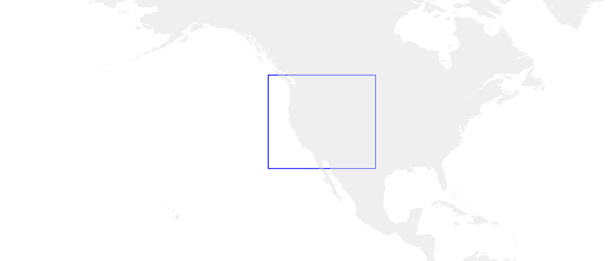

```r
land <- ne_download(scale = 50, type = 'land', category = 'physical', returnclass = 'sf')
land <- st_geometry(land)
plot(poly, border = 'blue', xpd = NA)
plot(land, border = NA, col = gray(0.9, alpha = 0.5), add = TRUE, xpd = NA)
```

Climate products are often not masked to terrestrial environments, so we may want to do so ourselves. One way to do this would be with the landmasses polygon we downloaded above. We will also crop our input rasters to the extent of our bounding box.

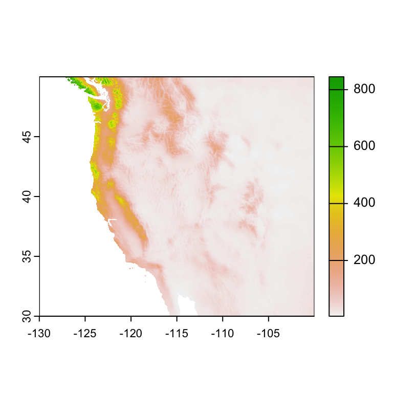

```r
# crop and mask input rasters
inputDir <- "./chelsaClim/global"

files <- list.files(inputDir, pattern = '.tif$', full.names = TRUE)

# As all rasters that we downloaded share the same reference grid, we can read in and process them all as a stack
clim <- rast(files)

# crop to poly and mask with land
clim <- crop(clim, poly)
clim <- mask(clim, vect(land))

# We will coarsen these rasters for the purposes of this tutorial.
clim <- aggregate(clim, 4)

# check an example
plot(clim[[1]])
```

Now all monthly rasters are clipped to the desired extent, and masked to terrestrial environments.

### Units

When working with climatic datasets for different time periods, it is imperative to have units that are in agreement. For instance, it is not uncommon to have data for the present in degrees C for temperature and in mm for precipitation, but to have temperature in degrees C * 10 for the past or future. In the case of climate layers from CHELSA, the documentation indicates that current climate temperature rasters are in degrees C, but that monthly temperature rasters for the LGM, for instance, are in degrees C / 10. Although there is capacity in the envirem R package to tell the functions what the units are, it is more straightforward to define the units as preferred ahead of time. Easiest might be to just have all monthly temperature rasters in deg C and precipitation rasters in mm, across all datasets you plan to work with. This is the stage at which this should happen.

We will now write our cropped and masked rasters to file. We will create an output folder called westernNA.

```r
outputDir <- "./chelsaClim/westernNA"
if (!dir.exists(outputDir)) {
  dir.create(outputDir)
}

# define file names
fn <- paste0(outputDir, '/', names(clim), '.tif')
writeRaster(clim, filename = fn, overwrite = TRUE)
```

## Raster naming scheme

The only requirement for the monthly climate raster file names is that they follow a standardized and predictable format: The different variables should have distinct names (precipitation vs min temperature vs max temperature, etc), and the numbers 1:12 should be present to indicate which month each raster corresponds to.

In the files downloaded and listed above, we can see that the naming scheme is as follows:

```r
names(clim)
```

```
##  [1] "CHELSA_pr_01_1981-2010_V.2.1"     "CHELSA_pr_02_1981-2010_V.2.1"
##  [3] "CHELSA_pr_03_1981-2010_V.2.1"     "CHELSA_pr_04_1981-2010_V.2.1"
##  [5] "CHELSA_pr_05_1981-2010_V.2.1"     "CHELSA_pr_06_1981-2010_V.2.1"
##  [7] "CHELSA_pr_07_1981-2010_V.2.1"     "CHELSA_pr_08_1981-2010_V.2.1"
##  [9] "CHELSA_pr_09_1981-2010_V.2.1"     "CHELSA_pr_10_1981-2010_V.2.1"
## [11] "CHELSA_pr_11_1981-2010_V.2.1"     "CHELSA_pr_12_1981-2010_V.2.1"
## [13] "CHELSA_tas_01_1981-2010_V.2.1"    "CHELSA_tas_02_1981-2010_V.2.1"
## [15] "CHELSA_tas_03_1981-2010_V.2.1"    "CHELSA_tas_04_1981-2010_V.2.1"
## [17] "CHELSA_tas_05_1981-2010_V.2.1"    "CHELSA_tas_06_1981-2010_V.2.1"
## [19] "CHELSA_tas_07_1981-2010_V.2.1"    "CHELSA_tas_08_1981-2010_V.2.1"
## [21] "CHELSA_tas_09_1981-2010_V.2.1"    "CHELSA_tas_10_1981-2010_V.2.1"
## [23] "CHELSA_tas_11_1981-2010_V.2.1"    "CHELSA_tas_12_1981-2010_V.2.1"
## [25] "CHELSA_tasmax_01_1981-2010_V.2.1" "CHELSA_tasmax_02_1981-2010_V.2.1"
## [27] "CHELSA_tasmax_03_1981-2010_V.2.1" "CHELSA_tasmax_04_1981-2010_V.2.1"
## [29] "CHELSA_tasmax_05_1981-2010_V.2.1" "CHELSA_tasmax_06_1981-2010_V.2.1"
## [31] "CHELSA_tasmax_07_1981-2010_V.2.1" "CHELSA_tasmax_08_1981-2010_V.2.1"
## [33] "CHELSA_tasmax_09_1981-2010_V.2.1" "CHELSA_tasmax_10_1981-2010_V.2.1"
## [35] "CHELSA_tasmax_11_1981-2010_V.2.1" "CHELSA_tasmax_12_1981-2010_V.2.1"
## [37] "CHELSA_tasmin_01_1981-2010_V.2.1" "CHELSA_tasmin_02_1981-2010_V.2.1"
## [39] "CHELSA_tasmin_03_1981-2010_V.2.1" "CHELSA_tasmin_04_1981-2010_V.2.1"
## [41] "CHELSA_tasmin_05_1981-2010_V.2.1" "CHELSA_tasmin_06_1981-2010_V.2.1"
## [43] "CHELSA_tasmin_07_1981-2010_V.2.1" "CHELSA_tasmin_08_1981-2010_V.2.1"
## [45] "CHELSA_tasmin_09_1981-2010_V.2.1" "CHELSA_tasmin_10_1981-2010_V.2.1"
## [47] "CHELSA_tasmin_11_1981-2010_V.2.1" "CHELSA_tasmin_12_1981-2010_V.2.1"
```

- precipitation: CHELSA_**pr**_**##**_1981-2010_V.2.1
- min temperature: CHELSA_**tasmin**_**##**_1981-2010_V.2.1
- max temperature: CHELSA_**tasmax**_**##**_1981-2010_V.2.1
- mean temperature: CHELSA_**tas**_**##**_1981-2010_V.2.1

… where `##` denotes the month number. The `##` symbol will be used to denote month, therefore it should not be present elsewhere in the file names.

In the envirem R package, we specify the naming scheme via the `assignNames()` function, which stores these names in a special R environment. This environment is then queried by the various envirem R functions. This only needs to be done once per R session – it is not necessary to do this for each call to particular functions.

The function `namingScheme()` returns the naming scheme that has been set. As we have not yet defined one, it lists the defaults:

```r
library(envirem)
namingScheme()
```

```
##
##
## variable   prefix        index   suffix
## ---------  -----------  -------  -------
## tmin:      tmin_          ##
## tmax:      tmax_          ##
## tmean:     tmean_         ##
## precip:    precip_        ##
## solrad:    et_solrad_     ##
## pet:       PET_           ##
```

```
##
##  To change these values, see ?assignNames.
```

This shows us the naming scheme for temperature and precipitation rasters, but also for solar radiation and potential evapotranspiration. We’ll get to the latter two later.

We can now assign our naming scheme

```r
assignNames(tmax = "CHELSA_tasmax_##_1981-2010_V.2.1",
            tmin = "CHELSA_mintas_##_1981-2010_V.2.1",
            tmean = "CHELSA_tas_##_1981-2010_V.2.1",
            precip = "CHELSA_pr_##_1981-2010_V.2.1",
            )

namingScheme()
```

```
##
##
## variable   prefix            index   suffix
## ---------  ---------------  -------  -----------------
## tmin:      CHELSA_mintas_     ##     _1981-2010_V.2.1
## tmax:      CHELSA_tasmax_     ##     _1981-2010_V.2.1
## tmean:     CHELSA_tas_        ##     _1981-2010_V.2.1
## precip:    CHELSA_pr_         ##     _1981-2010_V.2.1
## solrad:    et_solrad_         ##
## pet:       PET_               ##
```

```
##
##  To change these values, see ?assignNames.
```

We can verify that our naming scheme is properly recognizing the appropriate rasters. This function will print messages if the defined naming scheme does not match exactly with the rasters that would be expected.

```r
verifyRasterNames(clim)
```

```
##  The following rasters are missing or are not recognized: CHELSA_mintas_01_1981-2010_V.2.1, CHELSA_mintas_02_1981-2010_V.2.1, CHELSA_mintas_03_1981-2010_V.2.1, CHELSA_mintas_04_1981-2010_V.2.1, CHELSA_mintas_05_1981-2010_V.2.1, CHELSA_mintas_06_1981-2010_V.2.1, CHELSA_mintas_07_1981-2010_V.2.1, C…
##  Ensure that you have defined the proper naming scheme. See ?assignNames.
```

Here, the function could not find certain rasters that it deemed missing. In fact, what happened is we incorrectly defined the naming scheme for min temp above. Let’s fix that.

```r
assignNames(tmin = "CHELSA_tasmin_##_1981-2010_V.2.1")
namingScheme()
```

```
##
##
## variable   prefix            index   suffix
## ---------  ---------------  -------  -----------------
## tmin:      CHELSA_tasmin_     ##     _1981-2010_V.2.1
## tmax:      CHELSA_tasmax_     ##     _1981-2010_V.2.1
## tmean:     CHELSA_tas_        ##     _1981-2010_V.2.1
## precip:    CHELSA_pr_         ##     _1981-2010_V.2.1
## solrad:    et_solrad_         ##
## pet:       PET_               ##
```

```
##
##  To change these values, see ?assignNames.
```

```r
verifyRasterNames(clim)
```

```
##      Names appear to be correct!
```

Now we are all set.

## Solar radiation rasters

Previously, extraterrestrial solar radiation needed to be acquired elsewhere, but these can now be generated by the envirem R package, thanks to the [palinsol](https://cran.r-project.org/web/packages/palinsol/index.html) R package.

To generate monthly extraterrestrial solar radiation, we need to provide:

- a climatic raster, which will be used as a grid template,
- a year, which will be used to determine the angle of the sun,
- an output directory where the rasters will be written. The names of the output rasters will be defined by the naming scheme defined previously.

In the palinsol R package, `year = 0` corresponds to the year 1950. Therefore, as this is a climate projection for the years 1981-2010, we can define the year as 1995 - 1950 = 45.

```r
# we will use clim[[1]] as our template

# calculate monthly solar radiation, defined for the year 1995, output to the output directory
ETsolradRasters(rasterTemplate = clim[[1]], year = 45, outputDir = "./chelsaClim/westernNA", overwrite = TRUE)
```

```
## 1 2 3 4 5 6 7 8 9 10 11 12
```

```r
# let's read them in
solrad <- rast(list.files('./chelsaClim/westernNA', pattern = 'solrad', full.names = TRUE))
```

And we can verify the file structure again.

```r
verifyRasterNames(masterstack = clim, solradstack = solrad)
```

```
##      Names appear to be correct!
```

We are now ready to generate new variables.

## How is the envirem R package structured?

In the envirem R package, there are a number of functions to produce individual climatic variables, such as `embergerQ()`, `monthlyPET()`, `thermicityIndex()`, etc. These can be used on their own if the necessary input rasters are available as SpatRaster objects in R.

The function `generateEnvirem()` will take as input monthly temperature/precipitation/solar radiation rasters, and will output ENVIREM variables. This function will also calculate other variables that may be needed.

## Calling functions for individual variables

A number of envirem variables require as input some of the 19 bioclimatic variables. The user can either acquire those bioclimatic variables elsewhere, calculate them themselves (for example, by using the `biovars()` function in the [dismo](https://cran.r-project.org/web/packages/dismo/index.html) package), or have the envirem package calculate them via `generateEnvirem()`.

For example, if we were interested in calculating growing degree days, with a base temperature of 5 deg C, we can directly call the specific function:

```r
# Inputs needed will be monthly mean temperature only.

meanTempVar <- grep('tas_', names(clim), value = TRUE)
meanTempVar
```

```
##  [1] "CHELSA_tas_01_1981-2010_V.2.1" "CHELSA_tas_02_1981-2010_V.2.1"
##  [3] "CHELSA_tas_03_1981-2010_V.2.1" "CHELSA_tas_04_1981-2010_V.2.1"
##  [5] "CHELSA_tas_05_1981-2010_V.2.1" "CHELSA_tas_06_1981-2010_V.2.1"
##  [7] "CHELSA_tas_07_1981-2010_V.2.1" "CHELSA_tas_08_1981-2010_V.2.1"
##  [9] "CHELSA_tas_09_1981-2010_V.2.1" "CHELSA_tas_10_1981-2010_V.2.1"
## [11] "CHELSA_tas_11_1981-2010_V.2.1" "CHELSA_tas_12_1981-2010_V.2.1"
```

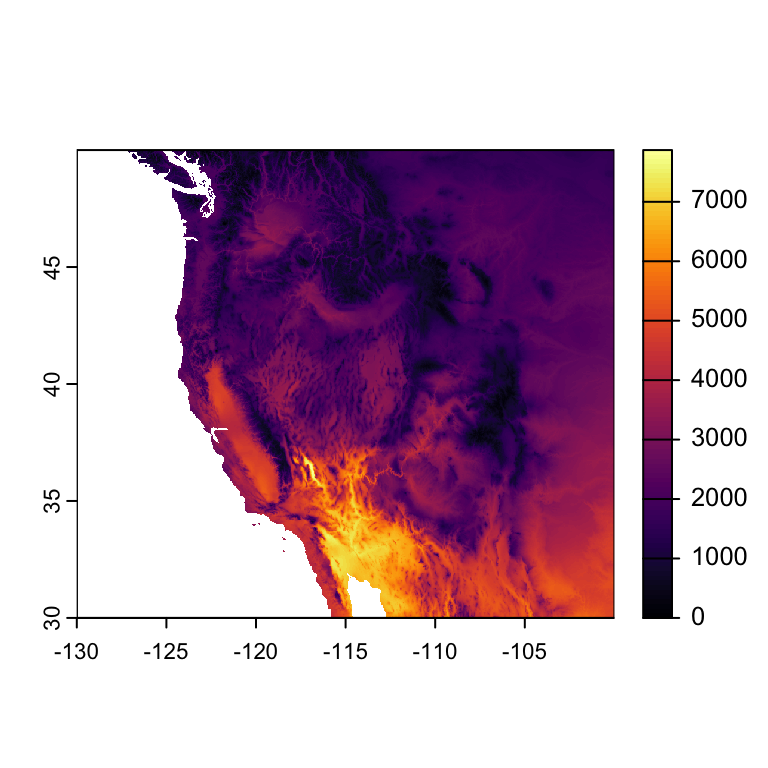

```r
gdd <- growingDegDays(clim[[meanTempVar]], baseTemp = 5)
plot(gdd, col = inferno(100))
```

Some other variables, such as the climatic moisture index, require as inputs bioclim 12 (annual precipitation) and annual PET (total annual potential evapotranspiration). If the user has these, then the function can be run directly with those inputs. Otherwise, the function `generateEnvirem()` will generate these intermediate products internally, based on the monthly rasters we are providing.

```r
cmi <- generateEnvirem(masterstack = clim, solradstack = solrad, var = 'climaticMoistureIndex')
```

```
##      ...splitting rasterstack...
```

```
##      ...calculating necessary bioclim variables...
```

```
##      ...annual PET...
```

```
##      ...climatic moisture index...
```

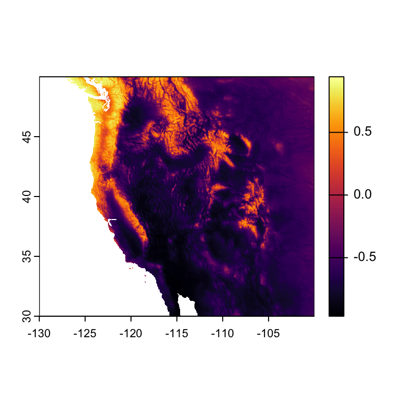

```r
plot(cmi, col = inferno(100))
```

## Generating multiple variables

You can use `generateEnvirem()` to produce any number of the envirem variables in one call. If you want to create all available variables, you can specify `var = 'all'`.

Here, we will create all variables, using `generateEnvirem()`. We will then write them to file.

```r
# create output directory
outdir <- './chelsaClim/westernNA_envirem'
if (!dir.exists(outdir)) {
  dir.create(outdir)
}

allGrids <- generateEnvirem(masterstack = clim, solradstack = solrad, var = 'all')
```

```
##      ...splitting rasterstack...
```

```
##      ...calculating necessary bioclim variables...
```

```
##      ...temp extremes...
```

```
##      ...growing degree days...
```

```
##      ...month count by deg...
```

```
##      ...continentality index...
```

```
##      ...thermicity index...
```

```
##      ...emberger's Q...
```

```
##      ...PET extremes...
```

```
##      ...annual PET...
```

```
##      ...PET seasonality...
```

```
##      ...climatic moisture index...
```

```
##      ...Thornthwaite aridity index...
```

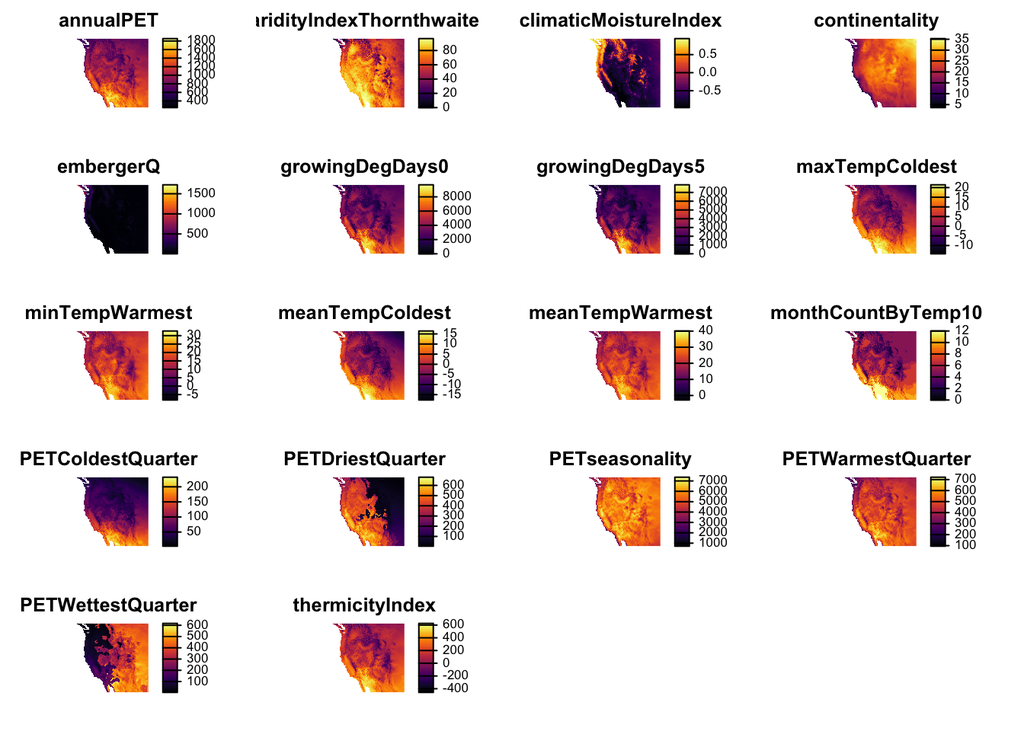

```r
par(mfrow = c(5, 4))

for (i in 1:nlyr(allGrids)) {
  plot(allGrids[[i]], col = inferno(100), box = FALSE, axes = FALSE)
  title(main = names(allGrids)[i], cex = 0.65)
}

filenames <- paste0(outdir, '/', names(allGrids), '.tif')
writeRaster(allGrids, filenames, overwrite = TRUE)
```